# Tools for interactively exploring R packages

Abstract

“Tools for interactively exploring R packages” published in R News.

## Introduction

An R package has the required and perhaps additional subdirectories containing files and information that may be of interest to users. Although these files can always be explored through command line operations both within and outside R, interactive tools that allow users to view and or operate on these files would be appealing to many users. Here we report on some widgets of this form that have been developed using the package *tcltk*. The functions are called `pExplorer`, `eExplorer`, and `vExplorer` and they are intended for exploring packages, examples and vignettes, respectively. These tools were developed as part of the Bioconductor project and are available in the package *tkWidgets* from www.bioconductor.org. Automatic downloading and package maintenance is also available using the *reposTools* mechanisms, also from Bioconductor.

## Description

Our current implementation is in the form of `tcl/tk` widgets and we are currently adding similar functionality to the *RGtk* package, also available from the Bioconductor website. Users must have a functioning implementation (and be configured for) `tcl/tk`. Once both *tkWidgets* and *widgetTools* have been loaded into the working session the user has full access to these interactive tools.

### pExplorer

`pExplorer` allows users to explore the contents of an R package. The widget can be invoked by providing a package name, a path to the directory containing the package, and the names of files and or subdirectory to be excluded from showing by the widget. The default behavior is to open the first package in the library of locally installed R (`.libPaths()`) with subdirectories/files named “Meta” and “latex” excluded if nothing is provided by a user.

Figure 1 shows the widget invoked by typing `pExplorer("base")`.

The following tasks can be performed through the interface:

- Typing in a valid path to a local directory containing R packages and then press the Enter key will update the name of the package being explored and show the contents of the first R package in the path in the Contents list box.
- Clicking the dropdown button for package path and selecting a path from the resulting dropdown list by double clicking will achieve the same results as typing in a new path.
- Clicking the Browse button allows users to selecting a directory containing R packages to achieve the same results as typing in a new path.
- Clicking the Select Package button allows users to pick a new package to explore and the name and contents of the package being explored are updated.

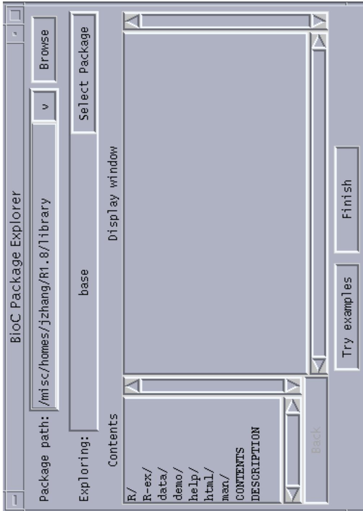

Figure 1: A snapshot of the widget when pExplorer is called

- Double clicking an item in the Contents list box results in different responses depending on the nature of the item being clicked. If the item is a subdirectory, the Contents will be updated with the contents of the subdirectory corresponding to the item just being clicked and the Back right below the list box will be activated. If the item is a file, the contents of the file will be displayed in the Display window text box.
- Clicking the Back button allows users to go back to the parent of the subdirectory whose contents are being displayed in Contents list box.
- Clicking the Try examples button invokes eExplorer going to be discussed next.

### eExplorer

eExplorer allows users to explore the example code from all the help files for the specified package. When invoked by passing a valid package name, eExplorer will display the names of the files for example code stored in the R-ex subdirectory in the Example code chunk list box as shown by Figure 2.

Clicking an item in the list displays the code example in the R Source Code text box for users to view. Users may view the help file containing the example code by clicking the View Help button, execute the example code and have the output of the execution displayed in the Diaplay window by clicking the Execute Code button, or export the result of execution (if R objects have been created as the result of execution) to the global environment of the current R session by clicking the Export to R.

### vExplorer

vExplorer allows users to explore the vignettes for a given R package by taking the advantages of the functionalities provided by Sweave (Leisch, 2002, 2003). When vExplorer is invoked without a package name as shown in Figure 3, the names of all the installed R packages containing vignettes will be shown in the Package List list box. When vExplorer is invoked with a package name, the Vignette List list box will be populated with the names of vignettes of the package.

Clicking a package name in the list box shows the names of all the vignettes of the package in the Vignette List list box. When a vignette name is clicked, a new widget as shown by Figure 4 appears that allows users to perform the following tasks if the selected vignettes contains any execute-able code chunks:

- Clicking an active button in the Code Chunk text box displays the code chunk in the R Source Code text box for users to view.
- Clicking the View PDF buttons shows the pdf version of the vignette currently being explored.
- Clicking the Execute Code button executes the code shown in the text box and displays the results of the execution in Results of Execution.
- Clicking the Export to R button export the result of execution to the global environment of the current R session.

The evaluation model for code chunks in a vignette is that they are evaluated sequentially. In order to ensure sequential evaluation and to help guide the user in terms of which code chunk is active we inactivate all buttons except the one associated with the first unevaluated code chunk.

## References

- Friedrich Leisch. Sweave, part I: Mixing R and L<sup>A</sup>T<sub>E</sub>X. *R News*, 2(3):28–31, December 2002. URL http://CRAN.R-project.org/doc/Rnews/.
- Friedrich Leisch. Sweave, part II: Package vignettes. *R News*, 3(2):21–24, October 2003. URL http://CRAN.R-project.org/doc/Rnews/.

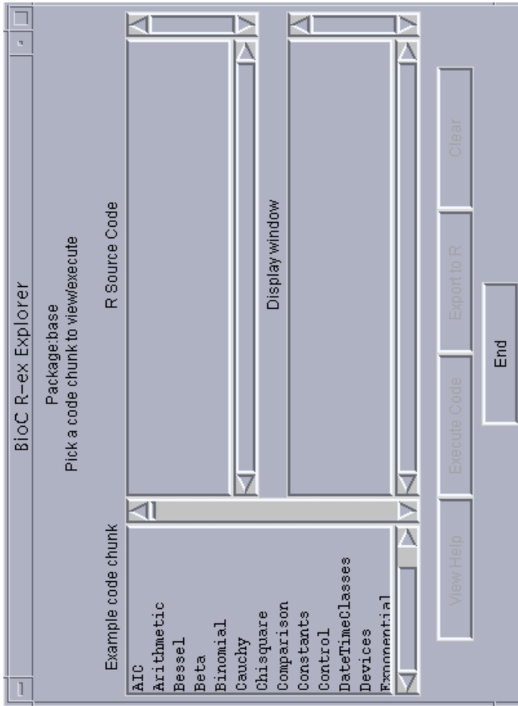

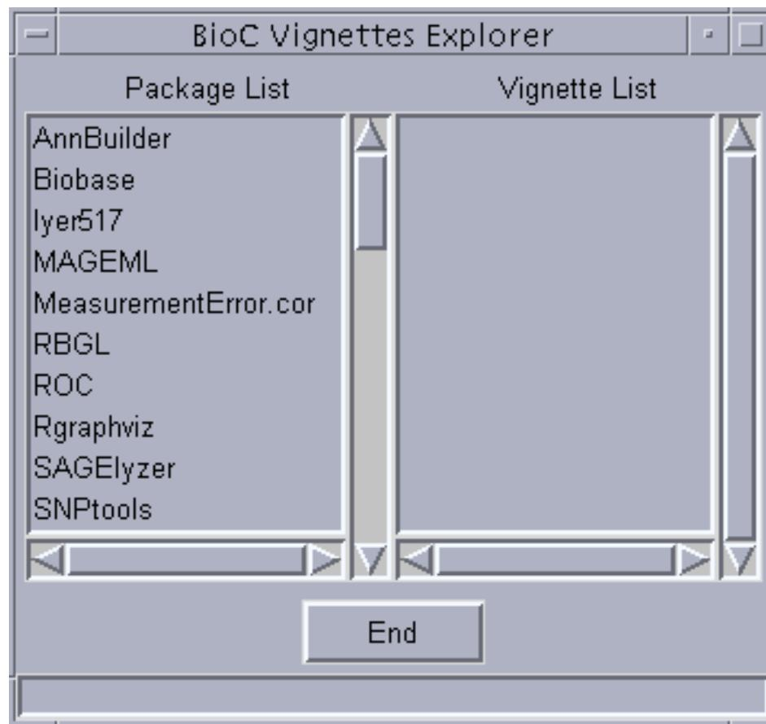

Figure 3: A snapshot of the widget when vExplorer is called by typing vExplorer()

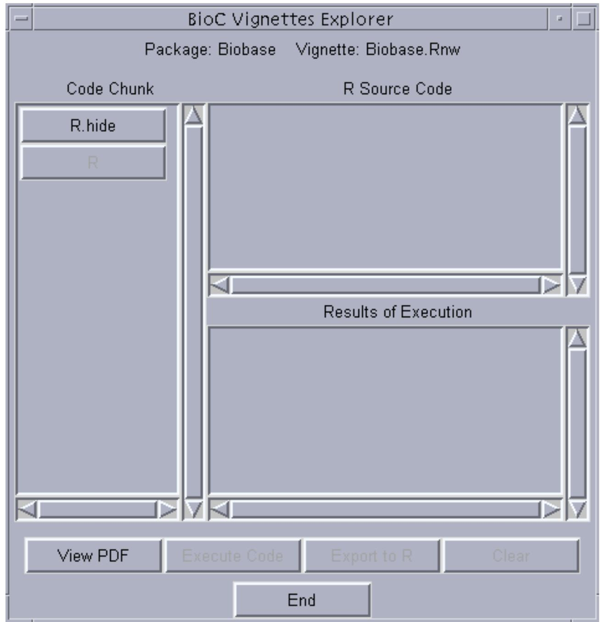

Figure 4: A snapshot of the widget when Biobase.Rnw of the Biobase package was clicked